# Data-607 Project-3

## —————————————————————————

### **Students Name :** Sachid Deshmukh, Mohammad Younus, Robert Lauto, Santosh Manjrekar, Olga Shiligin, Hantz Angrand

### **Date :** 10/18/2018

- > [GitHub Location for rmd file](https://github.com/mlforsachid/Data607-Project3/blob/master/Misc/Data607Project3.rmd)
- > [GitHub Location for pdf file](https://github.com/mlforsachid/Data607-Project3/blob/master/Misc/Data607Project3.pdf)
- > [RPubs location of published file](http://rpubs.com/sachid/Data607-Project3)
- > [Data File](https://media.githubusercontent.com/media/mlforsachid/Data607-Project3/master/Misc/globalterrorism.csv)

## —————————————————————————

### Context

Below example demonstrate what it takes from Data Scientist to analyze a given data and derive a meaningful information from the data. Data scientist frequently work with ambiguous data and are tasked to infer meaningful information from data. Let’s take example of The Global Terrorism Database (GTD).

This is an open-source database including information on terrorist attacks around the world from 1970 through 2017

The GTD includes systematic data on domestic as well as international terrorist incidents that have occurred during this time period and now includes more than 180,000 attacks. The database is maintained by researchers at the National Consortium for the Study of Terrorism and Responses to Terrorism (START), headquartered at the University of Maryland. [More Information](http://start.umd.edu/gtd)

Let’s see how a Data Scientist will approach this data set and what kind of insights can be obtained

### 1] Library Initialization

```r
library(ggplot2) # Data visualization
library(readr) # CSV file I/O, e.g. the read_csv function
library(tidyverse)
library(RCurl)
```

### 2] Load Data

```r
data.url = getURL("https://media.githubusercontent.com/media/mlforsachid/Data607-Project3/master/Misc/globalterrorism.csv")
attack <- read_csv(data.url,
  col_types = cols(
    nkill = col_double(),
    nhours = col_double(),
    propvalue = col_double(),
    nwound = col_double(),
    nperpcap= col_double(),
    nhostkid = col_double(),
    nreleased= col_double(),
    nkillter= col_double(),
    nkillus = col_double(),
    nwoundus = col_double(),
    ransomamt = col_double(),
    ransompaid= col_double(),
    nwoundte= col_double()
  )
)
```

### 3] Analyze success and failure rate

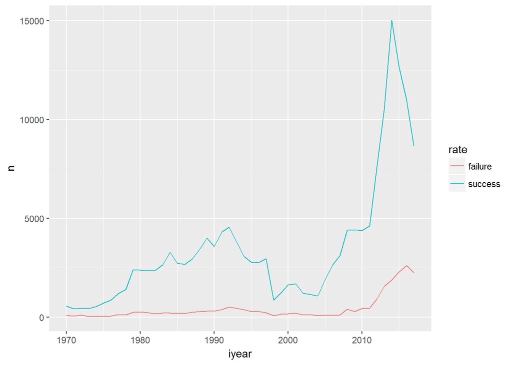

```r
attack %>%
  mutate(total = 1) %>% # total attacks that year (creates a new variable)
  count(iyear, wt=total-success) %>% # failed attempt
  cbind("failure") -> failure
  colnames(failure)[3] <- "rate"

attack %>%
  count(iyear, wt = success) %>%
  cbind("success")-> success
colnames(success)[3] <- "rate"

rbind(failure,success) %>%
  ggplot(aes(iyear, n)) +
  geom_line(aes(group=rate, colour=rate))
```

```
## # A tibble: 529 x 3
## # Groups:   iyear, region_txt [529]
##    iyear region_txt                     n
##    <int> <chr>                      <int>
##  1  2014 Middle East & North Africa  6939
##  2  2016 Middle East & North Africa  6115
##  3  2015 Middle East & North Africa  6036
##  4  2014 South Asia                  4998
##  5  2013 South Asia                  4612
##  6  2015 South Asia                  4585
##  7  2013 Middle East & North Africa  4560
##  8  2012 South Asia                  3803
##  9  2017 Middle East & North Africa  3780
## 10  2016 South Asia                  3639
## # ... with 519 more rows
```

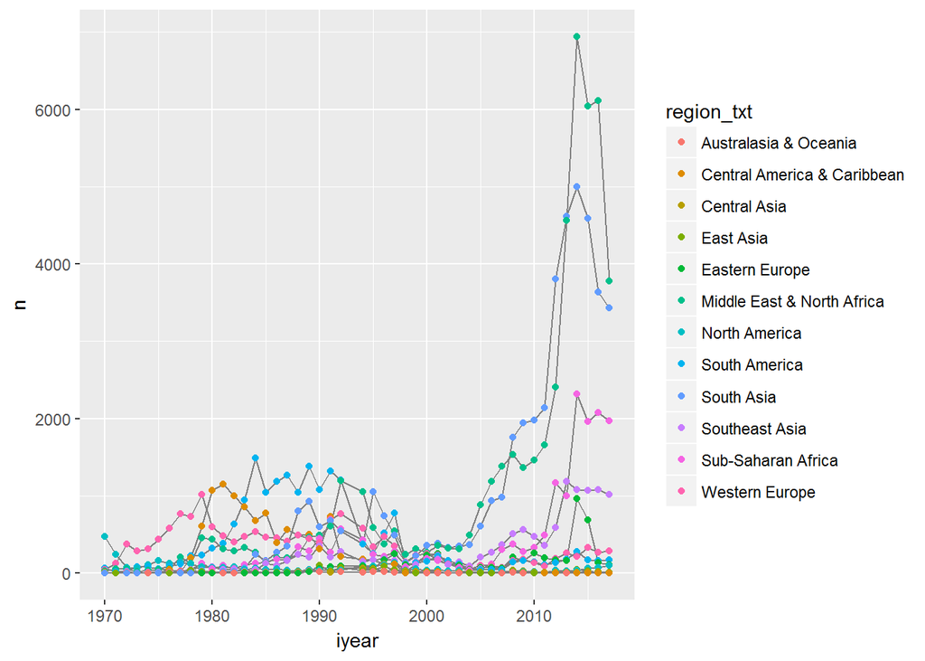

```r
attack %>%
  group_by(iyear,region_txt) %>% # allow operations to be performed by groups
  count() %>% # In case, count success rate conditional on the year and country
  arrange(desc(n))%>%  # arrange in descending order
  print(n = 10)%>% # print
  ggplot(aes(iyear, n)) +  # x axis- year, y = success rate
  geom_line(aes(group = region_txt), colour = "grey50") +
  geom_point(aes(colour = region_txt))
```

```
## # A tibble: 126 x 3
## # Groups:   iyear, country_txt [126]
##    iyear country_txt        n
##    <int> <chr>          <int>
##  1  1970 United Kingdom    12
##  2  1970 United States    468
##  3  1971 United Kingdom    81
##  4  1971 United States    247
##  5  1972 United Kingdom   292
##  6  1972 United States     68
##  7  1973 United Kingdom   189
##  8  1973 United States     58
##  9  1974 Singapore          1
## 10  1974 United Kingdom   203
## # ... with 116 more rows
```

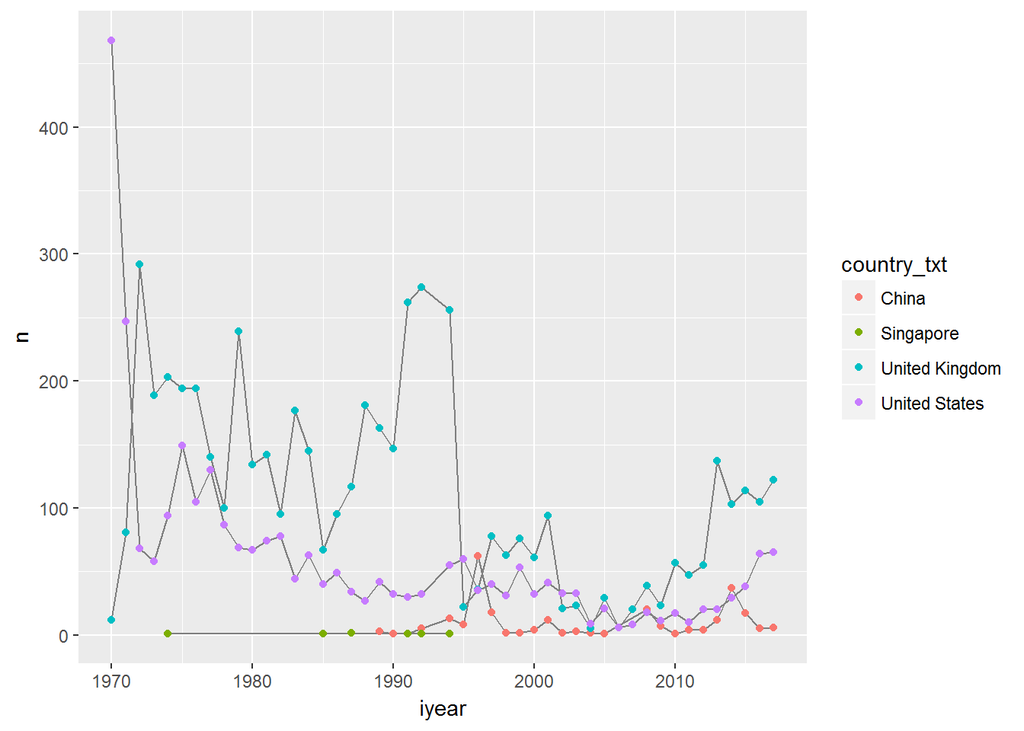

```r
attack %>%
  # With multiple conditions for filter, make sure to use %in% and not ==
filter(parse_character(country_txt) %in% c("Singapore", "China","United States","United Kingdom")) %>% # select four countries
  group_by(iyear,country_txt) %>% # allow operations to be performed by groups
  count() %>% # In case, count success rate conditional on the year and country
  print(n = 10)%>%
  ggplot(aes(iyear, n)) +  # x axis- year, y = success rate
  geom_line(aes(group = country_txt), colour = "grey50") +
  geom_point(aes(colour = country_txt))
```

### 6] Attack Type

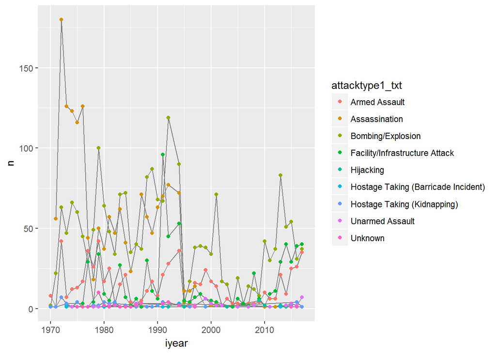

```r
attack %>%
  # With multiple conditions for filter, make sure to use %in% and not ==
  filter(parse_character(country_txt) %in% c("United Kingdom")) %>% # select four countries
  group_by(iyear,attacktype1_txt) %>% # allow operations to be performed by groups
  count() %>% # In case, count success rate conditional on the year and attacktype1_txt
  ggplot(aes(iyear, n)) +  # x axis- year, y = success rate
  geom_line(aes(group = attacktype1_txt), colour = "grey50") +
  geom_point(aes(colour = attacktype1_txt))
```

### 7] Attack Agenda

```
## # A tibble: 63 x 3
## # Groups:   iyear, crit1 [63]
##   iyear crit1     n
##   <int> <int> <int>
## 1  1970     1    12
## 2  1971     1    81
## 3  1972     1   292
## 4  1973     1   189
## 5  1974     1   203
## # ... with 58 more rows
```

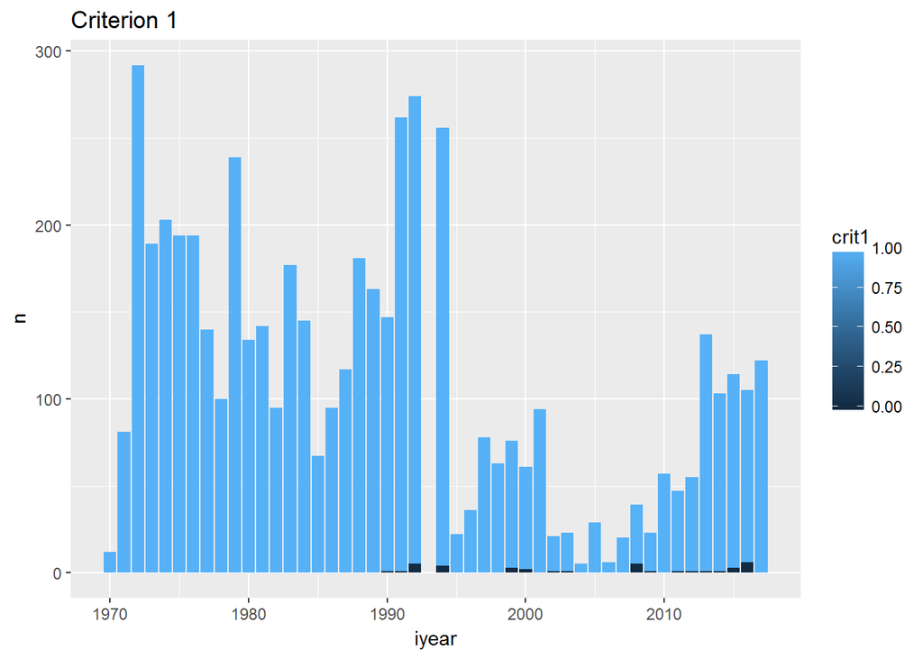

```r
# Criterion 1: POLITICAL, ECONOMIC, RELIGIOUS, OR SOCIAL GOAL (CRIT1)
# 1 =   The incident meets Criterion 1.
# 0 = "No   The incident does not meet Criterion 1.
attack %>%
# With multiple conditions for filter, make sure to use %in% and not ==
filter(parse_character(country_txt) %in% c("United Kingdom")) %>% # select four countries
group_by(iyear,crit1) %>% # allow operations to be performed by groups
count() %>% # In case, count success rate conditional on the year and crit1
print(n=5) %>%
ggplot(aes(iyear, n, fill=crit1)) +  # x axis- year, y = success rate
geom_bar(stat="identity") +  # stacking on top of each other
  ggtitle("Criterion 1")
```

### 8] Most frequent attack

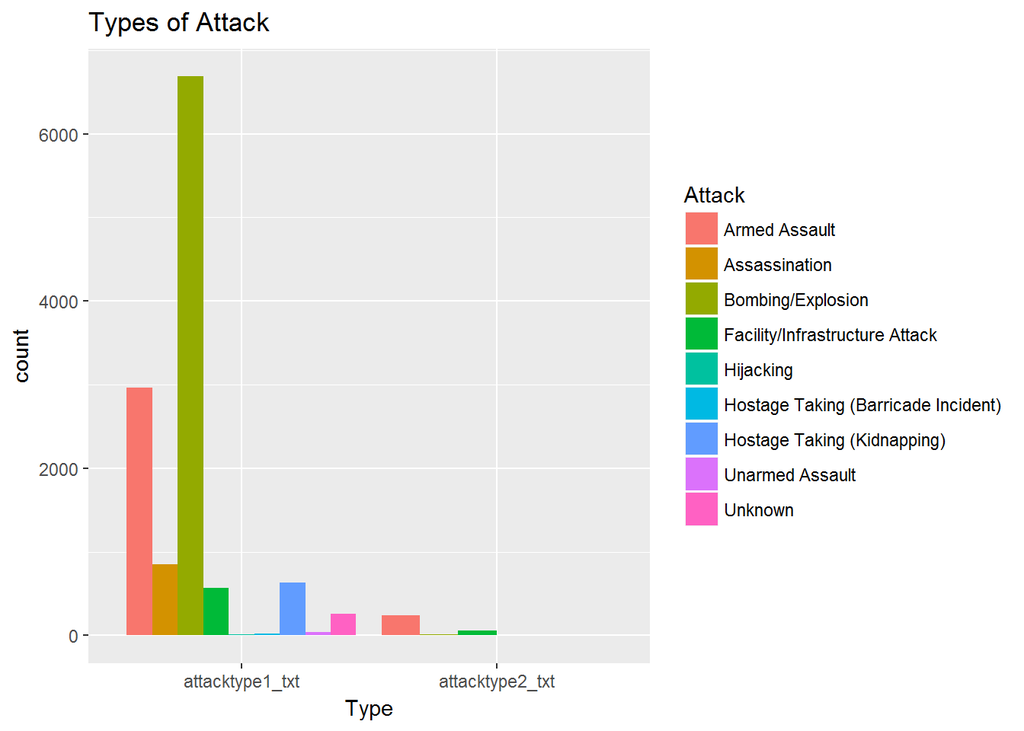

```r
attack %>%
  select(iyear, attacktype1_txt, attacktype2_txt) %>% # select variable
  filter(iyear == 2013) %>% # subset by rows based on condition
  gather(attacktype1_txt,attacktype2_txt, key = 'Type', value = 'Attack') %>% # transform wide to long
  filter(Attack != ".") %>% # remove all '.'
  ggplot(aes(x=Type, fill=Attack)) + geom_bar(position = "dodge") +# plot
  ggtitle("Types of Attack")
```

### 9] Attack Locations Bar Plot

```r
attack %>%
    select(iyear, country_txt, city) %>% # select variable
    filter(country_txt == "United Kingdom") %>%
    group_by(city)%>% # group by city
    count() %>% # count the number of times a city appear
    arrange(desc(n)) %>% # subset by rows based on condition
    head(n=10) -> state
  state
```

```
## # A tibble: 10 x 2
## # Groups:   city [10]
##    city            n
##    <chr>       <int>
##  1 Belfast      2170
##  2 London        399
##  3 Londonderry   366
##  4 Armagh        125
##  5 Newry         112
##  6 Unknown        90
##  7 Lurgan         71
##  8 Crossmaglen    65
##  9 Strabane       65
## 10 Dungannon      62
```

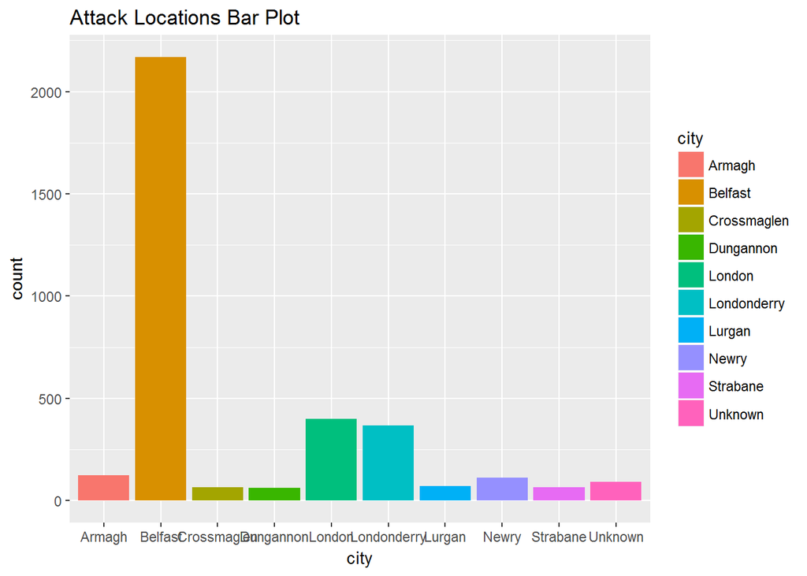

```r
  ## plot top 10
  attack %>%
    filter(country_txt == "United Kingdom") %>%
    select(iyear, city)%>%
    filter(city %in% state$city) %>%
    ggplot(aes(x=city, fill=city)) + geom_bar() +# plot
    ggtitle("Attack Locations Bar Plot")
```

### 10] Attack Timeline by city

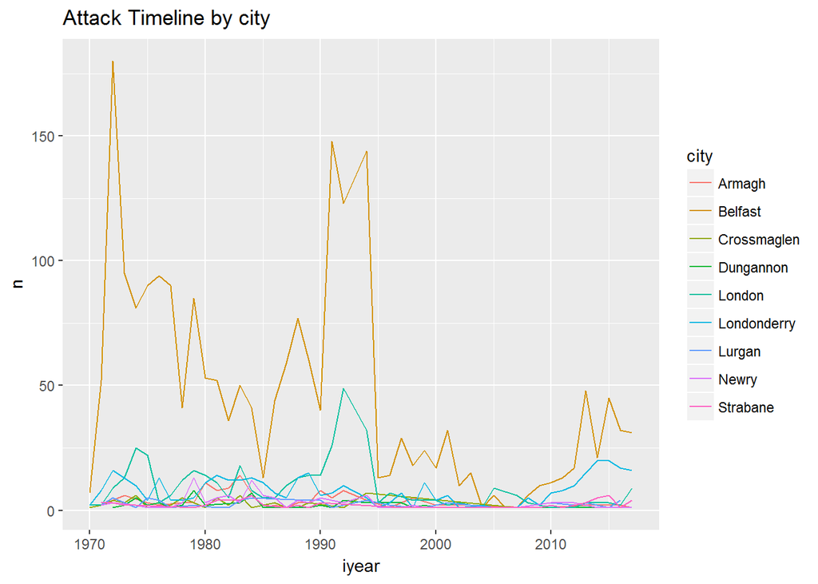

```r
attack%>%
      select(iyear, country_txt, city) %>% # select variable
      filter(country_txt == "United Kingdom") %>%
      group_by(city) %>% # group by city
      count() %>% # count the number of times a city appear
      arrange(desc(n))%>% # subset by rows based on condition
      head(n=10) -> state ## plot top 10

    attack %>%
      filter(country_txt == "United Kingdom") %>%
      select(iyear, city)%>%
      filter(city %in% state$city) %>% # select top 10
      filter(city !="Unknown") %>% # remove unknown
      group_by(iyear,city) %>%  #group to do calculations
      count() %>% # count
      ggplot(aes(x=iyear, y=n)) + geom_line(aes(color=city)) +# plot
      ggtitle("Attack Timeline by city")
```

### 11] Conclusion

From the above example it can be concluded that key Data Science skills which comes handy in any data explorations are below 1] Data Understanding - In depth understanding of the data 2] Technical knowhow - Well versed with technology for data wrangling 3] Data Cleanup and Data imputation - Skilled in advance data imputations techniques to fill missing data 4] Data Visualization - Ability to visualize data on multiple faucets to gain additional insights 5] Data Comparison - Compare meaningful metrics side by side to set important statistics apart 6] Critical Thinking - Ability to come up with multiple questions and sought answers for those through data statistics